# Optimal Treatment Analysis

## Outcome Variable

**Outcome Variable:** haz

## Predictor Variables

**Intervention Variable:** fage

**Adjustment Set:**

- arm
- W_mage
- meducyrs
- feducyrs
- W_mhtcm
- W_mwtkg
- W_mbmi
- W_fhtcm
- single
- brthmon
- delta_W_mage
- delta_meducyrs
- delta_feducyrs
- delta_W_mhtcm
- delta_W_mwtkg
- delta_W_mbmi
- delta_W_fhtcm
- delta_single
- delta_brthmon

## Stratifying Variables

The analysis was stratified on these variable(s):

- agecat
- studyid
- country

## Data Summary

| agecat | studyid | country | fage | n_cell | n |
| --- | --- | --- | --- | --- | --- |
| Birth | ki0047075b-MAL-ED | BANGLADESH | >=38 | 67 | 145 |
| Birth | ki0047075b-MAL-ED | BANGLADESH | <32 | 27 | 145 |
| Birth | ki0047075b-MAL-ED | BANGLADESH | [32-38) | 51 | 145 |
| Birth | ki0047075b-MAL-ED | BRAZIL | >=38 | 27 | 68 |
| Birth | ki0047075b-MAL-ED | BRAZIL | <32 | 16 | 68 |
| Birth | ki0047075b-MAL-ED | BRAZIL | [32-38) | 25 | 68 |
| Birth | ki0047075b-MAL-ED | INDIA | >=38 | 27 | 131 |
| Birth | ki0047075b-MAL-ED | INDIA | <32 | 44 | 131 |
| Birth | ki0047075b-MAL-ED | INDIA | [32-38) | 60 | 131 |
| Birth | ki0047075b-MAL-ED | NEPAL | >=38 | 13 | 61 |
| Birth | ki0047075b-MAL-ED | NEPAL | <32 | 9 | 61 |
| Birth | ki0047075b-MAL-ED | NEPAL | [32-38) | 39 | 61 |
| Birth | ki0047075b-MAL-ED | PERU | >=38 | 27 | 80 |
| Birth | ki0047075b-MAL-ED | PERU | <32 | 27 | 80 |
| Birth | ki0047075b-MAL-ED | PERU | [32-38) | 26 | 80 |
| Birth | ki0047075b-MAL-ED | SOUTH AFRICA | >=38 | 53 | 76 |
| Birth | ki0047075b-MAL-ED | SOUTH AFRICA | <32 | 8 | 76 |
| Birth | ki0047075b-MAL-ED | SOUTH AFRICA | [32-38) | 15 | 76 |
| Birth | ki0047075b-MAL-ED | TANZANIA, UNITED REPUBLIC OF | >=38 | 21 | 46 |
| Birth | ki0047075b-MAL-ED | TANZANIA, UNITED REPUBLIC OF | <32 | 6 | 46 |
| Birth | ki0047075b-MAL-ED | TANZANIA, UNITED REPUBLIC OF | [32-38) | 19 | 46 |
| Birth | ki1000304b-SAS-CompFeed | INDIA | >=38 | 4 | 187 |
| Birth | ki1000304b-SAS-CompFeed | INDIA | <32 | 152 | 187 |
| Birth | ki1000304b-SAS-CompFeed | INDIA | [32-38) | 31 | 187 |
| Birth | ki1119695-PROBIT | BELARUS | >=38 | 606 | 13390 |
| Birth | ki1119695-PROBIT | BELARUS | <32 | 10724 | 13390 |
| Birth | ki1119695-PROBIT | BELARUS | [32-38) | 2060 | 13390 |
| Birth | ki1135781-COHORTS | GUATEMALA | >=38 | 245 | 823 |
| Birth | ki1135781-COHORTS | GUATEMALA | <32 | 380 | 823 |
| Birth | ki1135781-COHORTS | GUATEMALA | [32-38) | 198 | 823 |

[output cut: 75 more lines]

The following strata were considered:

- agecat: 24 months, studyid: ki0047075b-MAL-ED, country: BANGLADESH
- agecat: 24 months, studyid: ki0047075b-MAL-ED, country: BRAZIL
- agecat: 24 months, studyid: ki0047075b-MAL-ED, country: INDIA
- agecat: 24 months, studyid: ki0047075b-MAL-ED, country: NEPAL
- agecat: 24 months, studyid: ki0047075b-MAL-ED, country: PERU
- agecat: 24 months, studyid: ki0047075b-MAL-ED, country: SOUTH AFRICA
- agecat: 24 months, studyid: ki0047075b-MAL-ED, country: TANZANIA, UNITED REPUBLIC OF
- agecat: 24 months, studyid: ki1119695-PROBIT, country: BELARUS
- agecat: 24 months, studyid: ki1135781-COHORTS, country: GUATEMALA
- agecat: 24 months, studyid: ki1135781-COHORTS, country: PHILIPPINES
- agecat: 24 months, studyid: ki1148112-LCNI-5, country: MALAWI
- agecat: 6 months, studyid: ki0047075b-MAL-ED, country: BANGLADESH
- agecat: 6 months, studyid: ki0047075b-MAL-ED, country: BRAZIL
- agecat: 6 months, studyid: ki0047075b-MAL-ED, country: INDIA
- agecat: 6 months, studyid: ki0047075b-MAL-ED, country: NEPAL
- agecat: 6 months, studyid: ki0047075b-MAL-ED, country: PERU
- agecat: 6 months, studyid: ki0047075b-MAL-ED, country: SOUTH AFRICA
- agecat: 6 months, studyid: ki0047075b-MAL-ED, country: TANZANIA, UNITED REPUBLIC OF
- agecat: 6 months, studyid: ki1000304b-SAS-CompFeed, country: INDIA
- agecat: 6 months, studyid: ki1000304b-SAS-FoodSuppl, country: INDIA
- agecat: 6 months, studyid: ki1119695-PROBIT, country: BELARUS
- agecat: 6 months, studyid: ki1135781-COHORTS, country: GUATEMALA
- agecat: 6 months, studyid: ki1135781-COHORTS, country: PHILIPPINES
- agecat: 6 months, studyid: ki1148112-LCNI-5, country: MALAWI
- agecat: Birth, studyid: ki0047075b-MAL-ED, country: BANGLADESH
- agecat: Birth, studyid: ki0047075b-MAL-ED, country: BRAZIL
- agecat: Birth, studyid: ki0047075b-MAL-ED, country: INDIA
- agecat: Birth, studyid: ki0047075b-MAL-ED, country: NEPAL
- agecat: Birth, studyid: ki0047075b-MAL-ED, country: PERU
- agecat: Birth, studyid: ki0047075b-MAL-ED, country: SOUTH AFRICA
- agecat: Birth, studyid: ki0047075b-MAL-ED, country: TANZANIA, UNITED REPUBLIC OF
- agecat: Birth, studyid: ki1000304b-SAS-CompFeed, country: INDIA
- agecat: Birth, studyid: ki1119695-PROBIT, country: BELARUS
- agecat: Birth, studyid: ki1135781-COHORTS, country: GUATEMALA
- agecat: Birth, studyid: ki1135781-COHORTS, country: PHILIPPINES

### Dropped Strata

Some strata were dropped due to rare outcomes:

- agecat: Birth, studyid: ki1000304b-SAS-CompFeed, country: INDIA

## Methods Detail

We’re interested in the causal parameters $E[Y_a]$ for all values of $a \in \mathcal{A}$. These parameters represent the mean outcome if, possibly contrary to fact, we intervened to set all units to have $A=a$. Under the randomization and positivity assumptions, these are identified by the statistical parameters $\psi_a=E_W[E_{Y|A,W}(Y|A=a,W)]$. In addition, we’re interested in the mean of $Y$, $E[Y]$ under no intervention (the observed mean). We will estimate these parameters by using SuperLearner to fit the relevant likelihood factors – $E_{Y|A,W}(Y|A=a,W)$ and $p(A=a|W)$, and then updating our likelihood fit using a joint TMLE.

For unadjusted analyses ($W=\{\}$), initial likelihoods were estimated using Lrnr_glm to estimate the simple $E(Y|A)$ and Lrnr_mean to estimate $p(A)$. For adjusted analyses, a small library containing Lrnr_glmnet, Lrnr_xgboost, and Lrnr_mean was used.

Having estimated these parameters, we will then use the delta method to estimate relative risks and attributable risks relative to a prespecified baseline level of $A$.

# Results Detail

## Results Plots

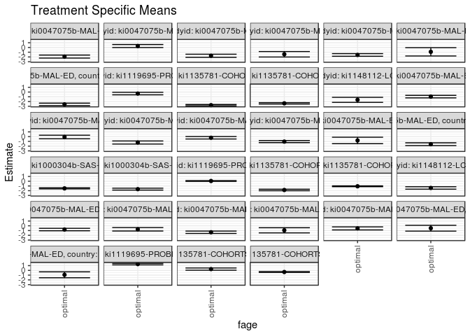

## Results Table

### Parameter: TSM

| agecat | studyid | country | intervention_level | baseline_level | estimate | ci_lower | ci_upper |
| --- | --- | --- | --- | --- | --- | --- | --- |
| Birth | ki0047075b-MAL-ED | BANGLADESH | optimal | observed | -0.7855620 | -1.0441780 | -0.5269460 |
| Birth | ki0047075b-MAL-ED | BRAZIL | optimal | observed | -0.7348455 | -1.0938708 | -0.3758202 |
| Birth | ki0047075b-MAL-ED | INDIA | optimal | observed | -1.3593827 | -1.6094483 | -1.1093171 |
| Birth | ki0047075b-MAL-ED | NEPAL | optimal | observed | -0.9516729 | -1.4948395 | -0.4085064 |
| Birth | ki0047075b-MAL-ED | PERU | optimal | observed | -0.5466896 | -0.8678227 | -0.2255564 |
| Birth | ki0047075b-MAL-ED | SOUTH AFRICA | optimal | observed | -0.5035616 | -1.1180251 | 0.1109019 |
| Birth | ki0047075b-MAL-ED | TANZANIA, UNITED REPUBLIC OF | optimal | observed | -0.9291583 | -1.5538912 | -0.3044255 |
| Birth | ki1119695-PROBIT | BELARUS | optimal | observed | 1.3199437 | 1.1647693 | 1.4751182 |
| Birth | ki1135781-COHORTS | GUATEMALA | optimal | observed | 0.2702372 | 0.0335188 | 0.5069556 |
| Birth | ki1135781-COHORTS | PHILIPPINES | optimal | observed | -0.3418596 | -0.4390757 | -0.2446435 |
| 6 months | ki0047075b-MAL-ED | BANGLADESH | optimal | observed | -0.9632046 | -1.2330144 | -0.6933948 |
| 6 months | ki0047075b-MAL-ED | BRAZIL | optimal | observed | -0.0758321 | -0.4513936 | 0.2997294 |
| 6 months | ki0047075b-MAL-ED | INDIA | optimal | observed | -1.2362452 | -1.5594160 | -0.9130744 |
| 6 months | ki0047075b-MAL-ED | NEPAL | optimal | observed | -0.2368941 | -0.4976722 | 0.0238841 |
| 6 months | ki0047075b-MAL-ED | PERU | optimal | observed | -1.0434679 | -1.2592435 | -0.8276922 |
| 6 months | ki0047075b-MAL-ED | SOUTH AFRICA | optimal | observed | -0.8062497 | -1.4856427 | -0.1268567 |
| 6 months | ki0047075b-MAL-ED | TANZANIA, UNITED REPUBLIC OF | optimal | observed | -1.5913493 | -1.8820258 | -1.3006729 |
| 6 months | ki1000304b-SAS-CompFeed | INDIA | optimal | observed | -1.5064150 | -1.6224324 | -1.3903976 |
| 6 months | ki1000304b-SAS-FoodSuppl | INDIA | optimal | observed | -1.6705674 | -1.8704988 | -1.4706361 |
| 6 months | ki1119695-PROBIT | BELARUS | optimal | observed | 0.0470435 | -0.0430562 | 0.1371432 |
| 6 months | ki1135781-COHORTS | GUATEMALA | optimal | observed | -1.8472700 | -2.0072847 | -1.6872554 |
| 6 months | ki1135781-COHORTS | PHILIPPINES | optimal | observed | -1.0651455 | -1.1508963 | -0.9793948 |
| 6 months | ki1148112-LCNI-5 | MALAWI | optimal | observed | -1.4165974 | -1.6711319 | -1.1620628 |
| 24 months | ki0047075b-MAL-ED | BANGLADESH | optimal | observed | -1.9198632 | -2.2380591 | -1.6016673 |
| 24 months | ki0047075b-MAL-ED | BRAZIL | optimal | observed | 0.2994503 | -0.0179776 | 0.6168781 |
| 24 months | ki0047075b-MAL-ED | INDIA | optimal | observed | -1.7478486 | -2.0735111 | -1.4221861 |
| 24 months | ki0047075b-MAL-ED | NEPAL | optimal | observed | -1.4329049 | -2.0083017 | -0.8575081 |
| 24 months | ki0047075b-MAL-ED | PERU | optimal | observed | -1.5716807 | -1.8493251 | -1.2940363 |
| 24 months | ki0047075b-MAL-ED | SOUTH AFRICA | optimal | observed | -0.9172722 | -1.7931325 | -0.0414119 |
| 24 months | ki0047075b-MAL-ED | TANZANIA, UNITED REPUBLIC OF | optimal | observed | -2.5947656 | -2.8555611 | -2.3339702 |
| 24 months | ki1119695-PROBIT | BELARUS | optimal | observed | -0.3196611 | -0.5868642 | -0.0524580 |
| 24 months | ki1135781-COHORTS | GUATEMALA | optimal | observed | -2.7633981 | -2.9055365 | -2.6212597 |
| 24 months | ki1135781-COHORTS | PHILIPPINES | optimal | observed | -2.3797871 | -2.5239601 | -2.2356141 |
| 24 months | ki1148112-LCNI-5 | MALAWI | optimal | observed | -1.6434026 | -2.1736641 | -1.1131411 |

### Parameter: E(Y)

| agecat | studyid | country | intervention_level | baseline_level | estimate | ci_lower | ci_upper |
| --- | --- | --- | --- | --- | --- | --- | --- |
| Birth | ki0047075b-MAL-ED | BANGLADESH | observed | observed | -0.9778621 | -1.1318533 | -0.8238709 |
| Birth | ki0047075b-MAL-ED | BRAZIL | observed | observed | -0.7238235 | -0.9850427 | -0.4626043 |
| Birth | ki0047075b-MAL-ED | INDIA | observed | observed | -0.9720611 | -1.1477959 | -0.7963262 |
| Birth | ki0047075b-MAL-ED | NEPAL | observed | observed | -0.7244262 | -0.9767822 | -0.4720703 |
| Birth | ki0047075b-MAL-ED | PERU | observed | observed | -0.9256250 | -1.1260052 | -0.7252448 |
| Birth | ki0047075b-MAL-ED | SOUTH AFRICA | observed | observed | -0.7181579 | -0.9588306 | -0.4774852 |
| Birth | ki0047075b-MAL-ED | TANZANIA, UNITED REPUBLIC OF | observed | observed | -0.7745652 | -1.0958030 | -0.4533274 |
| Birth | ki1119695-PROBIT | BELARUS | observed | observed | 1.3342255 | 1.1742855 | 1.4941656 |
| Birth | ki1135781-COHORTS | GUATEMALA | observed | observed | 0.1377035 | 0.0520086 | 0.2233984 |
| Birth | ki1135781-COHORTS | PHILIPPINES | observed | observed | -0.2468988 | -0.2865742 | -0.2072233 |
| 6 months | ki0047075b-MAL-ED | BANGLADESH | observed | observed | -1.1979000 | -1.3314769 | -1.0643231 |
| 6 months | ki0047075b-MAL-ED | BRAZIL | observed | observed | 0.0554008 | -0.1690575 | 0.2798592 |
| 6 months | ki0047075b-MAL-ED | INDIA | observed | observed | -1.1894617 | -1.3346428 | -1.0442806 |
| 6 months | ki0047075b-MAL-ED | NEPAL | observed | observed | -0.7256962 | -0.9111717 | -0.5402207 |
| 6 months | ki0047075b-MAL-ED | PERU | observed | observed | -1.3300201 | -1.5375346 | -1.1225056 |
| 6 months | ki0047075b-MAL-ED | SOUTH AFRICA | observed | observed | -0.9083333 | -1.1234247 | -0.6932420 |
| 6 months | ki0047075b-MAL-ED | TANZANIA, UNITED REPUBLIC OF | observed | observed | -1.4744833 | -1.6639782 | -1.2849884 |
| 6 months | ki1000304b-SAS-CompFeed | INDIA | observed | observed | -1.4006377 | -1.4802862 | -1.3209891 |
| 6 months | ki1000304b-SAS-FoodSuppl | INDIA | observed | observed | -1.8986842 | -2.0118892 | -1.7854792 |
| 6 months | ki1119695-PROBIT | BELARUS | observed | observed | 0.1166130 | 0.0230160 | 0.2102100 |
| 6 months | ki1135781-COHORTS | GUATEMALA | observed | observed | -1.8068353 | -1.8758487 | -1.7378219 |
| 6 months | ki1135781-COHORTS | PHILIPPINES | observed | observed | -1.1421265 | -1.1845116 | -1.0997415 |
| 6 months | ki1148112-LCNI-5 | MALAWI | observed | observed | -1.6211321 | -1.8052501 | -1.4370141 |
| 24 months | ki0047075b-MAL-ED | BANGLADESH | observed | observed | -1.9567550 | -2.0984173 | -1.8150926 |
| 24 months | ki0047075b-MAL-ED | BRAZIL | observed | observed | 0.1588608 | -0.0651474 | 0.3828689 |
| 24 months | ki0047075b-MAL-ED | INDIA | observed | observed | -1.8373292 | -1.9909581 | -1.6837003 |
| 24 months | ki0047075b-MAL-ED | NEPAL | observed | observed | -1.5030380 | -1.6956243 | -1.3104516 |
| 24 months | ki0047075b-MAL-ED | PERU | observed | observed | -1.6960127 | -1.8853995 | -1.5066258 |
| 24 months | ki0047075b-MAL-ED | SOUTH AFRICA | observed | observed | -1.4697191 | -1.6840618 | -1.2553764 |
| 24 months | ki0047075b-MAL-ED | TANZANIA, UNITED REPUBLIC OF | observed | observed | -2.7318500 | -2.9253580 | -2.5383420 |
| 24 months | ki1119695-PROBIT | BELARUS | observed | observed | -0.1254844 | -0.4225624 | 0.1715937 |
| 24 months | ki1135781-COHORTS | GUATEMALA | observed | observed | -2.8513770 | -2.9170436 | -2.7857104 |
| 24 months | ki1135781-COHORTS | PHILIPPINES | observed | observed | -2.3958878 | -2.4412250 | -2.3505506 |
| 24 months | ki1148112-LCNI-5 | MALAWI | observed | observed | -1.7689189 | -1.9714091 | -1.5664287 |

### Parameter: PAR

| agecat | studyid | country | intervention_level | baseline_level | estimate | ci_lower | ci_upper |
| --- | --- | --- | --- | --- | --- | --- | --- |
| Birth | ki0047075b-MAL-ED | BANGLADESH | optimal | observed | -0.1923001 | -0.3918105 | 0.0072103 |
| Birth | ki0047075b-MAL-ED | BRAZIL | optimal | observed | 0.0110220 | -0.3096315 | 0.3316755 |
| Birth | ki0047075b-MAL-ED | INDIA | optimal | observed | 0.3873217 | 0.1557832 | 0.6188602 |
| Birth | ki0047075b-MAL-ED | NEPAL | optimal | observed | 0.2272467 | -0.2909631 | 0.7454564 |
| Birth | ki0047075b-MAL-ED | PERU | optimal | observed | -0.3789354 | -0.6750450 | -0.0828258 |
| Birth | ki0047075b-MAL-ED | SOUTH AFRICA | optimal | observed | -0.2145963 | -0.8197507 | 0.3905581 |
| Birth | ki0047075b-MAL-ED | TANZANIA, UNITED REPUBLIC OF | optimal | observed | 0.1545931 | -0.2699420 | 0.5791282 |
| Birth | ki1119695-PROBIT | BELARUS | optimal | observed | 0.0142818 | -0.0461488 | 0.0747124 |
| Birth | ki1135781-COHORTS | GUATEMALA | optimal | observed | -0.1325337 | -0.3587578 | 0.0936904 |
| Birth | ki1135781-COHORTS | PHILIPPINES | optimal | observed | 0.0949608 | 0.0024543 | 0.1874673 |
| 6 months | ki0047075b-MAL-ED | BANGLADESH | optimal | observed | -0.2346954 | -0.4776527 | 0.0082619 |
| 6 months | ki0047075b-MAL-ED | BRAZIL | optimal | observed | 0.1312330 | -0.1742628 | 0.4367287 |
| 6 months | ki0047075b-MAL-ED | INDIA | optimal | observed | 0.0467835 | -0.2321281 | 0.3256951 |
| 6 months | ki0047075b-MAL-ED | NEPAL | optimal | observed | -0.4888021 | -0.7492033 | -0.2284009 |
| 6 months | ki0047075b-MAL-ED | PERU | optimal | observed | -0.2865522 | -0.5462532 | -0.0268513 |
| 6 months | ki0047075b-MAL-ED | SOUTH AFRICA | optimal | observed | -0.1020836 | -0.7625910 | 0.5584237 |
| 6 months | ki0047075b-MAL-ED | TANZANIA, UNITED REPUBLIC OF | optimal | observed | 0.1168660 | -0.1177522 | 0.3514842 |
| 6 months | ki1000304b-SAS-CompFeed | INDIA | optimal | observed | 0.1057773 | -0.0179218 | 0.2294765 |
| 6 months | ki1000304b-SAS-FoodSuppl | INDIA | optimal | observed | -0.2281168 | -0.4289358 | -0.0272977 |
| 6 months | ki1119695-PROBIT | BELARUS | optimal | observed | 0.0695695 | -0.0208546 | 0.1599936 |
| 6 months | ki1135781-COHORTS | GUATEMALA | optimal | observed | 0.0404347 | -0.1002399 | 0.1811094 |
| 6 months | ki1135781-COHORTS | PHILIPPINES | optimal | observed | -0.0769810 | -0.1536347 | -0.0003273 |
| 6 months | ki1148112-LCNI-5 | MALAWI | optimal | observed | -0.2045347 | -0.4702462 | 0.0611767 |
| 24 months | ki0047075b-MAL-ED | BANGLADESH | optimal | observed | -0.0368918 | -0.3078977 | 0.2341141 |
| 24 months | ki0047075b-MAL-ED | BRAZIL | optimal | observed | -0.1405895 | -0.4315134 | 0.1503344 |
| 24 months | ki0047075b-MAL-ED | INDIA | optimal | observed | -0.0894806 | -0.3908422 | 0.2118811 |
| 24 months | ki0047075b-MAL-ED | NEPAL | optimal | observed | -0.0701331 | -0.5618635 | 0.4215973 |
| 24 months | ki0047075b-MAL-ED | PERU | optimal | observed | -0.1243319 | -0.3848368 | 0.1361729 |
| 24 months | ki0047075b-MAL-ED | SOUTH AFRICA | optimal | observed | -0.5524469 | -1.3827596 | 0.2778658 |
| 24 months | ki0047075b-MAL-ED | TANZANIA, UNITED REPUBLIC OF | optimal | observed | -0.1370844 | -0.3405538 | 0.0663851 |
| 24 months | ki1119695-PROBIT | BELARUS | optimal | observed | 0.1941768 | 0.0148338 | 0.3735197 |
| 24 months | ki1135781-COHORTS | GUATEMALA | optimal | observed | -0.0879788 | -0.2186220 | 0.0426644 |
| 24 months | ki1135781-COHORTS | PHILIPPINES | optimal | observed | -0.0161007 | -0.1533395 | 0.1211381 |
| 24 months | ki1148112-LCNI-5 | MALAWI | optimal | observed | -0.1255163 | -0.5902229 | 0.3391903 |